# Asociación e independencia entre variables

Docente: Felipe Calvo Cepeda - fcalvoc@unal.edu.co | Universidad Nacional de Colombia

## Propósito de esta práctica

La asociación describe cómo cambian conjuntamente dos variables. La forma de resumirla depende del tipo de variables:

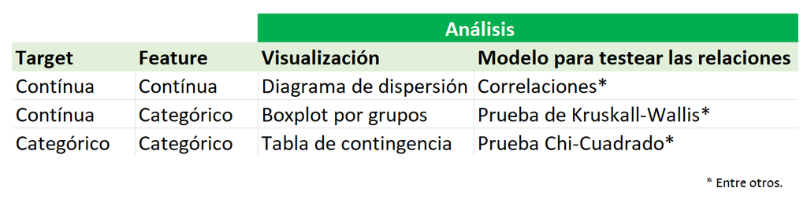

## Cargar librerías y datos, y prepararlos

```r
# Cargo tidyverse
library("tidyverse")

# Cargo datos
read_delim(
  file = "data/winequality-red.csv",
  delim = ",",
  locale=locale(decimal_mark = ".")
  ) -> wine_raw

# Quitamos espacios en los nombres de las variables y los reemplazamos por un guion bajo
names(wine_raw) <- str_replace_all(names(wine_raw), c(" " = "_"))

# Preparo los datos, creando dos variables cualitativas a partir de las cuantitativas (con fines pedagógicos)
## Partimos de la base de datos 'wine_raw'
## y la ontroducimos a un algoritmo de operaciones
wine_raw %>%
  ## mutate() crea una nueva variable llamada 'calidad'
  ## basada en los rangos ya conocidos de la variable quality
  mutate(
    calidad = ifelse(
      quality == '3' | quality == '4','baja',
      ifelse(
        quality == '5' | quality == '6','media',
        'alta'))
  ) %>%
  ## mutate_at() recibe la columna 'calidad' y la convierte en un factor
  mutate_at('calidad', factor) %>%

  ## mutate() crea una nueva variable llamada 'acetico'
  ## basada en rangos conocidos de la variable 'volatile_acidity'
  mutate(
    acetico = ifelse(volatile_acidity < 0.7, 'bajo', 'alto')
  ) %>%
  ## mutate_at() recibe la columna 'acetico' y la convierte en un factor
  ## el resultado de todas las operaciones se guarda en 'wine_processed'
  mutate_at('acetico', factor) -> wine_processed

# Especificamos el orden de los factores que acabamos de crear
wine_processed$calidad <- factor(wine_processed$calidad, levels = c("baja","media","alta"))
wine_processed$acetico <- factor(wine_processed$acetico, levels = c("bajo","alto"))

glimpse(wine_processed)
```

[output not shown]

## Información sobre el conjunto de datos

### Información general

Los datos corresponden a una variación de un vino tradicional portugués llamado *“Vinho Verde”* proveniente de una región llamada Vinho, ubicada muy al norte de Portugal.

### Variables

- **fixed acidity**: ácidos del vino que no se evaporan fácilmente.
- **volatile acidity**: cantidad de ácido acético en el vino, el cual en altas cantidades genera sensaciones no placenteras y un sabor vinagroso.
- **citric acid**: cantidad de ácido cítrico en pequeñas cantidades, el cual añade cierta *frescura* y sabor al vino.
- **residual sugar**: cantidad de azucar residual luego del proceso de fermentación. Es raro tener menos de 1g/litro y los vinos con más de 45g/litro se consideran dulces.
- **chlorides**: cantidad de sal en el vino.
- **free sulfur dioxide**: cantidad de dióxido de azufre (S0<sub>2</sub>) libre, el cual previene el crecimiento de microbios y la oxidación del vino.
- **total sulfur dioxide**: cantidad total de dióxido de azufre (S0<sub>2</sub>) en forma libre y fija; en bajas concentraciones es indetectable, en concentraciones superiores a 50ppm el SO<sub>2</sub> es evidente para la nariz y el sabor del vino.
- **density**: la densidad del vino es cercana a la del agua dependiendo de la cantidad de azucar y alcohol.
- **pH**: describe qué tan ácido o básico es un vino en un escala desde cero (muy ácido) hasta 14 (muy básico); la gran mayoría de vinos tienen un pH entre 3-4.
- **sulphates**: un aditivo que contribuye a regular los niveles de dióxido de azufre (S0<sub>2</sub>), el cual actúa como antimicrobios y antioxidante.
- **alcohol**: porcentaje del alcohol del vino.
- **quality**: puntuación del vino basada en datos sensoriales, en una escala entre 0 y 10.

### Fuente

Cortez, P., Cerdeira, A., Almeida, F., Matos, T., & Reis, J. (2009). Modeling wine preferences by data mining from physicochemical properties. Decision Support Systems, 47(4), 547-553.

> Note que es **muy importante** tener un contexto sobre el conjunto de datos.

## Análisis descriptivo

### Resumen numérico

El método **summary()** que trae por defecto R nos brinda estadísticas de resumen para cada una de las variables de nuestro conjunto de datos.

```r
## Resumen básico de datos
summary(wine_processed)
```

```
##  fixed_acidity   volatile_acidity  citric_acid    residual_sugar
##  Min.   : 4.60   Min.   :0.1200   Min.   :0.000   Min.   : 0.900
##  1st Qu.: 7.10   1st Qu.:0.3900   1st Qu.:0.090   1st Qu.: 1.900
##  Median : 7.90   Median :0.5200   Median :0.260   Median : 2.200
##  Mean   : 8.32   Mean   :0.5278   Mean   :0.271   Mean   : 2.539
##  3rd Qu.: 9.20   3rd Qu.:0.6400   3rd Qu.:0.420   3rd Qu.: 2.600
##  Max.   :15.90   Max.   :1.5800   Max.   :1.000   Max.   :15.500
##    chlorides       free_sulfur_dioxide total_sulfur_dioxide    density
##  Min.   :0.01200   Min.   : 1.00       Min.   :  6.00       Min.   :0.9901
##  1st Qu.:0.07000   1st Qu.: 7.00       1st Qu.: 22.00       1st Qu.:0.9956
##  Median :0.07900   Median :14.00       Median : 38.00       Median :0.9968
##  Mean   :0.08747   Mean   :15.87       Mean   : 46.47       Mean   :0.9967
##  3rd Qu.:0.09000   3rd Qu.:21.00       3rd Qu.: 62.00       3rd Qu.:0.9978
##  Max.   :0.61100   Max.   :72.00       Max.   :289.00       Max.   :1.0037
##        pH          sulphates         alcohol         quality       calidad
##  Min.   :2.740   Min.   :0.3300   Min.   : 8.40   Min.   :3.000   baja :  63
##  1st Qu.:3.210   1st Qu.:0.5500   1st Qu.: 9.50   1st Qu.:5.000   media:1319
##  Median :3.310   Median :0.6200   Median :10.20   Median :6.000   alta : 217
##  Mean   :3.311   Mean   :0.6581   Mean   :10.42   Mean   :5.636
##  3rd Qu.:3.400   3rd Qu.:0.7300   3rd Qu.:11.10   3rd Qu.:6.000
##  Max.   :4.010   Max.   :2.0000   Max.   :14.90   Max.   :8.000
##  acetico
##  bajo:1366
##  alto: 233
##
##
##
##
```

### Resumen gráfico

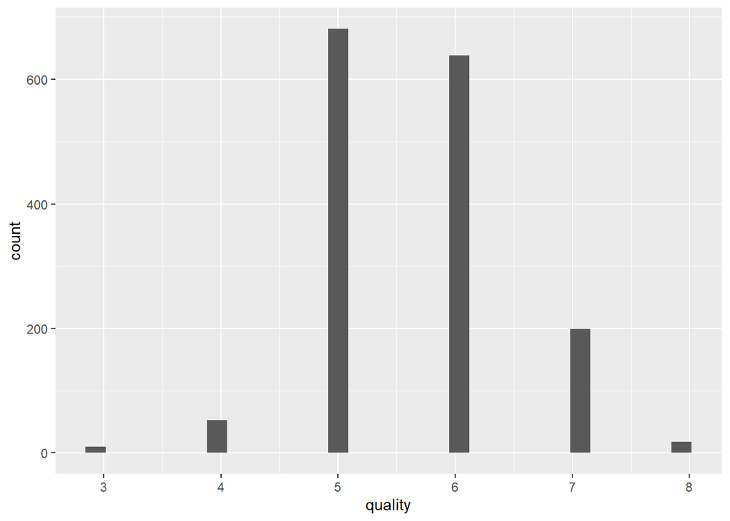

```r
## Cargamos la librería ggplot2
library(ggplot2)

## Usamos el método para graficar histogramas
## Seleccionamos como objetivo la variable quality
ggplot(wine_processed, aes(quality)) +
    geom_histogram()
```

> Note que podemos hacer histogramas para las demás variables. Además, podríamos realizar otros tipos de gráficos univariados.

> Nuestro interés ahora será construir resúmenes numéricos y resúmenes gráficos entre dos o más variables.

## Relación entre variables

En una investigación o estudio podemos estar interesados en analizar cómo un conjunto de variables se relaciona con una variable particular de interés (**target / label / variable crítica / variable explicada**). Una parte esencial de la fase de análisis consiste en identificar qué variables presentan una mayor asociación o capacidad explicativa respecto de la variable de interés.

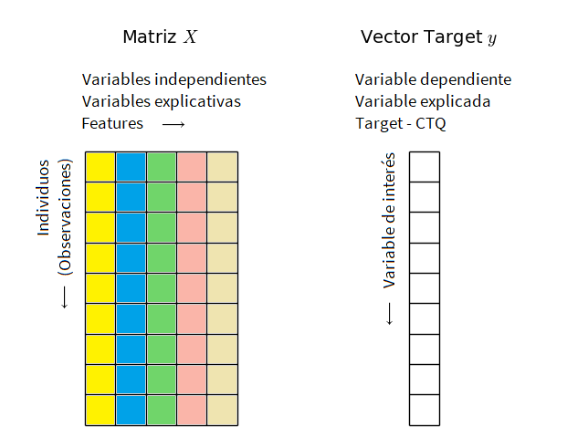

Existen diversas herramientas estadísticas para analizar la relación entre dos o más variables, cuya elección depende del tipo de variables y del objetivo del análisis.

Antes de explorar dichas herramientas, conviene hacer una revisión sobre algunos conceptos.

## Caso 1: Asociación entre dos variables contínuas

A nivel gráfico, conviene “cruzar” ambas variables usando **diagramas de dispersión**.

Son útiles porque al combinar los valores de un par de variables podemos encontrar posibles relaciones matemáticas entre ellas.

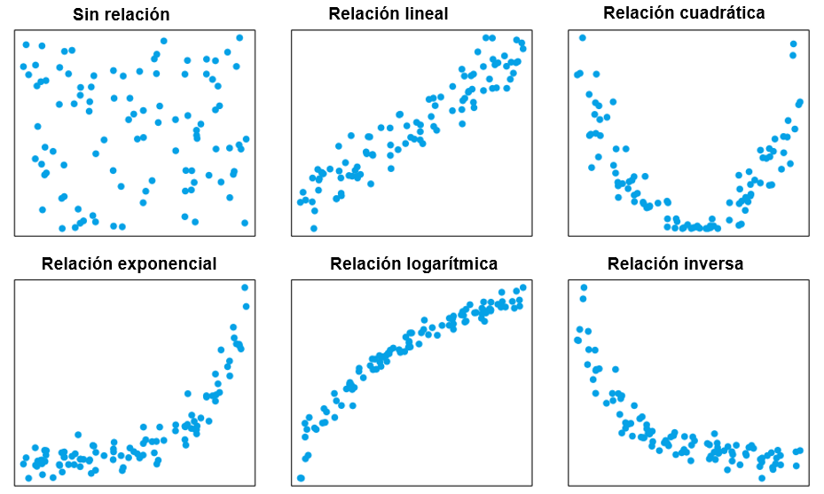

Exploremos las relaciones entre algunas variables del conjunto de datos y la variable de interés *quality*.

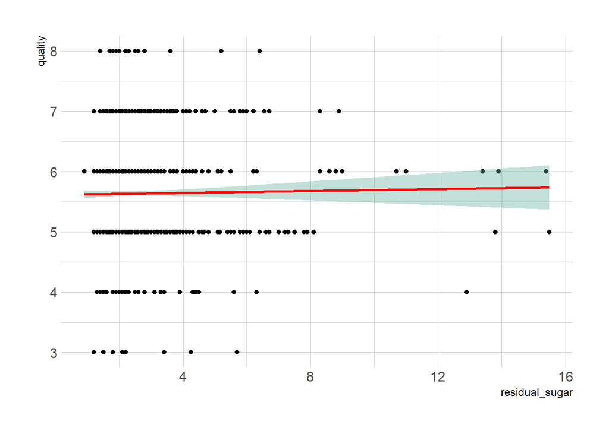

```r
# install.packages("hrbrthemes")
library(hrbrthemes)

## Una relación lineal inexistente
ggplot(wine_processed, aes(x=residual_sugar, y=quality)) +
  geom_point() +
  geom_smooth(method=lm , color="red", fill="#69b3a2", se=TRUE) +
  theme_ipsum()
```

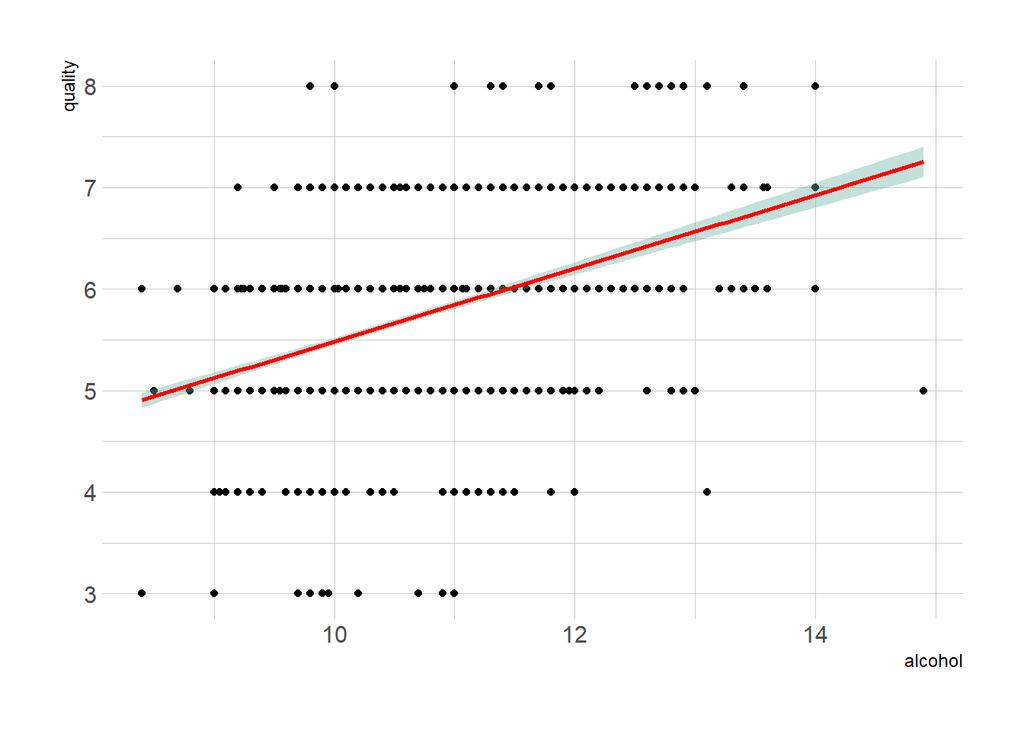

```r
## Una relación lineal positiva
ggplot(wine_processed, aes(x=alcohol, y=quality)) +
  geom_point() +
  geom_smooth(method=lm , color="red", fill="#69b3a2", se=TRUE) +
  theme_ipsum()
```

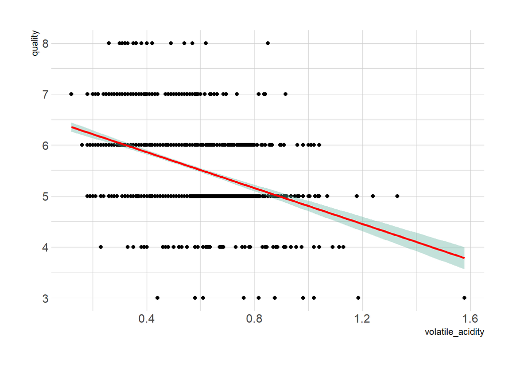

```r
## Una relación lineal negativa
ggplot(wine_processed, aes(x=volatile_acidity, y=quality)) +
  geom_point() +
  geom_smooth(method=lm , color="red", fill="#69b3a2", se=TRUE) +
  theme_ipsum()
```

Para medir el grado de relación en este escenario, se suelen calcular **coeficientes de correlación**.

Generalmente:

- Una **correlación positiva** entre dos variables indica que a medida que los valores de una variable crecen los valores de la otra variable también crecen. Y viceversa. El máximo valor de una correlación positiva es 1.
- Una **correlación negativa** entre dos variables indica que a medida que los valores de una variable crecen los valores de la otra variable decrecen. El máximo valor de una correlación negativa es -1.
- Una **correlación de cero** entre dos variables indica que no existe una asociación lineal entre ellas.

**Cálculo de correlaciones en R**

```r
## Correlaciones entre dos variables
cor(wine_processed$fixed_acidity, wine_processed$quality, method = 'pearson')
```

```
## [1] 0.1240516
```

```r
cor(wine_processed$chlorides, wine_processed$quality, method = 'pearson')
```

```
## [1] -0.1289066
```

```r
## Matriz de correlaciones
## Note que filtramos la base de datos para solamente calcular correlaciones entre variables cuantitativas
cor(Filter(is.numeric, wine_processed), method = 'pearson')
```

```
##                      fixed_acidity volatile_acidity citric_acid residual_sugar
## fixed_acidity           1.00000000     -0.256130895  0.67170343    0.114776724
## volatile_acidity       -0.25613089      1.000000000 -0.55249568    0.001917882
## citric_acid             0.67170343     -0.552495685  1.00000000    0.143577162
## residual_sugar          0.11477672      0.001917882  0.14357716    1.000000000
## chlorides               0.09370519      0.061297772  0.20382291    0.055609535
## free_sulfur_dioxide    -0.15379419     -0.010503827 -0.06097813    0.187048995
## total_sulfur_dioxide   -0.11318144      0.076470005  0.03553302    0.203027882
## density                 0.66804729      0.022026232  0.36494718    0.355283371
## pH                     -0.68297819      0.234937294 -0.54190414   -0.085652422
## sulphates               0.18300566     -0.260986685  0.31277004    0.005527121
## alcohol                -0.06166827     -0.202288027  0.10990325    0.042075437
## quality                 0.12405165     -0.390557780  0.22637251    0.013731637
##                         chlorides free_sulfur_dioxide total_sulfur_dioxide
## fixed_acidity         0.093705186        -0.153794193          -0.11318144
## volatile_acidity      0.061297772        -0.010503827           0.07647000
## citric_acid           0.203822914        -0.060978129           0.03553302
## residual_sugar        0.055609535         0.187048995           0.20302788
## chlorides             1.000000000         0.005562147           0.04740047
## free_sulfur_dioxide   0.005562147         1.000000000           0.66766645
## total_sulfur_dioxide  0.047400468         0.667666450           1.00000000
## density               0.200632327        -0.021945831           0.07126948
## pH                   -0.265026131         0.070377499          -0.06649456
## sulphates             0.371260481         0.051657572           0.04294684
## alcohol              -0.221140545        -0.069408354          -0.20565394
## quality              -0.128906560        -0.050656057          -0.18510029
##                          density          pH    sulphates     alcohol
## fixed_acidity         0.66804729 -0.68297819  0.183005664 -0.06166827
## volatile_acidity      0.02202623  0.23493729 -0.260986685 -0.20228803
## citric_acid           0.36494718 -0.54190414  0.312770044  0.10990325
## residual_sugar        0.35528337 -0.08565242  0.005527121  0.04207544
## chlorides             0.20063233 -0.26502613  0.371260481 -0.22114054
## free_sulfur_dioxide  -0.02194583  0.07037750  0.051657572 -0.06940835
## total_sulfur_dioxide  0.07126948 -0.06649456  0.042946836 -0.20565394
## density               1.00000000 -0.34169933  0.148506412 -0.49617977
## pH                   -0.34169933  1.00000000 -0.196647602  0.20563251
## sulphates             0.14850641 -0.19664760  1.000000000  0.09359475
## alcohol              -0.49617977  0.20563251  0.093594750  1.00000000
## quality              -0.17491923 -0.05773139  0.251397079  0.47616632
##                          quality
## fixed_acidity         0.12405165
## volatile_acidity     -0.39055778
## citric_acid           0.22637251
## residual_sugar        0.01373164
## chlorides            -0.12890656
## free_sulfur_dioxide  -0.05065606
## total_sulfur_dioxide -0.18510029
## density              -0.17491923
## pH                   -0.05773139
## sulphates             0.25139708
## alcohol               0.47616632
## quality               1.00000000
```

> Por defecto el método **cor()** calcula una correlación de Pearson, por tanto, el resultado numerico asume que la relación entre las variables es lineal. Dado que en la practica hay muchas relaciones no lineales, una forma más robusta de calcular la asociación es calculando una **correlación de Spearman** (*method = ‘spearman’*) o el estadístico **Tau de Kendall** (*method = ‘kendall’*).

**Otra forma más bonita de mostrar correlaciones usando el paquete correlation**

```r
# Instalamos el paquete correlation
install.packages("correlation")
```

```r
# Creamos una matriz detallada de correlaciones
# Note que acá no estamos filtrando las columnas numéricas como lo hicimos antes
# Esto debido a que el paquete automáticamente hace el filtrado. Uno debe verificar
correlaciones <- correlation(wine_processed)
correlaciones
```

```
## # Correlation Matrix (pearson-method)
##
## Parameter1           |           Parameter2 |        r |         95% CI | t(1597) |         p
## ---------------------------------------------------------------------------------------------
## fixed_acidity        |     volatile_acidity |    -0.26 | [-0.30, -0.21] |  -10.59 | < .001***
## fixed_acidity        |          citric_acid |     0.67 | [ 0.64,  0.70] |   36.23 | < .001***
## fixed_acidity        |       residual_sugar |     0.11 | [ 0.07,  0.16] |    4.62 | < .001***
## fixed_acidity        |            chlorides |     0.09 | [ 0.04,  0.14] |    3.76 | 0.005**
## fixed_acidity        |  free_sulfur_dioxide |    -0.15 | [-0.20, -0.11] |   -6.22 | < .001***
## fixed_acidity        | total_sulfur_dioxide |    -0.11 | [-0.16, -0.06] |   -4.55 | < .001***
## fixed_acidity        |              density |     0.67 | [ 0.64,  0.69] |   35.88 | < .001***
## fixed_acidity        |                   pH |    -0.68 | [-0.71, -0.66] |  -37.37 | < .001***
## fixed_acidity        |            sulphates |     0.18 | [ 0.14,  0.23] |    7.44 | < .001***
## fixed_acidity        |              alcohol |    -0.06 | [-0.11, -0.01] |   -2.47 | 0.246
## fixed_acidity        |              quality |     0.12 | [ 0.08,  0.17] |    5.00 | < .001***
## volatile_acidity     |          citric_acid |    -0.55 | [-0.59, -0.52] |  -26.49 | < .001***
## volatile_acidity     |       residual_sugar | 1.92e-03 | [-0.05,  0.05] |    0.08 | > .999
## volatile_acidity     |            chlorides |     0.06 | [ 0.01,  0.11] |    2.45 | 0.246
## volatile_acidity     |  free_sulfur_dioxide |    -0.01 | [-0.06,  0.04] |   -0.42 | > .999
## volatile_acidity     | total_sulfur_dioxide |     0.08 | [ 0.03,  0.13] |    3.06 | 0.051
## volatile_acidity     |              density |     0.02 | [-0.03,  0.07] |    0.88 | > .999
## volatile_acidity     |                   pH |     0.23 | [ 0.19,  0.28] |    9.66 | < .001***
## volatile_acidity     |            sulphates |    -0.26 | [-0.31, -0.21] |  -10.80 | < .001***
## volatile_acidity     |              alcohol |    -0.20 | [-0.25, -0.15] |   -8.25 | < .001***
## volatile_acidity     |              quality |    -0.39 | [-0.43, -0.35] |  -16.95 | < .001***
## citric_acid          |       residual_sugar |     0.14 | [ 0.10,  0.19] |    5.80 | < .001***
## citric_acid          |            chlorides |     0.20 | [ 0.16,  0.25] |    8.32 | < .001***
## citric_acid          |  free_sulfur_dioxide |    -0.06 | [-0.11, -0.01] |   -2.44 | 0.246
## citric_acid          | total_sulfur_dioxide |     0.04 | [-0.01,  0.08] |    1.42 | > .999
## citric_acid          |              density |     0.36 | [ 0.32,  0.41] |   15.66 | < .001***
## citric_acid          |                   pH |    -0.54 | [-0.58, -0.51] |  -25.77 | < .001***
## citric_acid          |            sulphates |     0.31 | [ 0.27,  0.36] |   13.16 | < .001***
## citric_acid          |              alcohol |     0.11 | [ 0.06,  0.16] |    4.42 | < .001***
## citric_acid          |              quality |     0.23 | [ 0.18,  0.27] |    9.29 | < .001***
## residual_sugar       |            chlorides |     0.06 | [ 0.01,  0.10] |    2.23 | 0.366
## residual_sugar       |  free_sulfur_dioxide |     0.19 | [ 0.14,  0.23] |    7.61 | < .001***
## residual_sugar       | total_sulfur_dioxide |     0.20 | [ 0.16,  0.25] |    8.29 | < .001***
## residual_sugar       |              density |     0.36 | [ 0.31,  0.40] |   15.19 | < .001***
## residual_sugar       |                   pH |    -0.09 | [-0.13, -0.04] |   -3.44 | 0.015*
## residual_sugar       |            sulphates | 5.53e-03 | [-0.04,  0.05] |    0.22 | > .999
```

[output cut: 18 more lines]

```
## total_sulfur_dioxide |              alcohol |    -0.21 | [-0.25, -0.16] |   -8.40 | < .001***
## total_sulfur_dioxide |              quality |    -0.19 | [-0.23, -0.14] |   -7.53 | < .001***
## density              |                   pH |    -0.34 | [-0.38, -0.30] |  -14.53 | < .001***
## density              |            sulphates |     0.15 | [ 0.10,  0.20] |    6.00 | < .001***
## density              |              alcohol |    -0.50 | [-0.53, -0.46] |  -22.84 | < .001***
## density              |              quality |    -0.17 | [-0.22, -0.13] |   -7.10 | < .001***
## pH                   |            sulphates |    -0.20 | [-0.24, -0.15] |   -8.02 | < .001***
## pH                   |              alcohol |     0.21 | [ 0.16,  0.25] |    8.40 | < .001***
## pH                   |              quality |    -0.06 | [-0.11, -0.01] |   -2.31 | 0.314
## sulphates            |              alcohol |     0.09 | [ 0.04,  0.14] |    3.76 | 0.005**
## sulphates            |              quality |     0.25 | [ 0.20,  0.30] |   10.38 | < .001***
## alcohol              |              quality |     0.48 | [ 0.44,  0.51] |   21.64 | < .001***
##
## p-value adjustment method: Holm (1979)
## Observations: 1599
```

> Que exista una asociación *fuerte* entre dos variables no implica una relación causal.

## Caso 2: Asociación entre una variable categórica y una variable contínua

A nivel gráfico, conviene “cruzar” ambas variables usando **boxplot por grupos**.

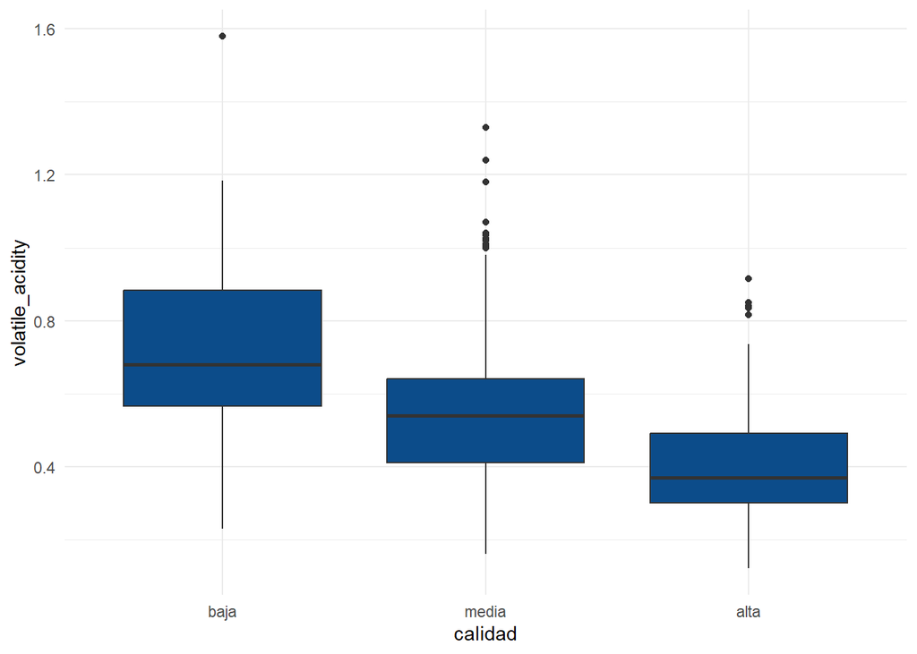

```r
ggplot(data = wine_processed) +
  aes(x = calidad, y = volatile_acidity) +
  geom_boxplot(fill = "#0c4c8a") +
  theme_minimal()
```

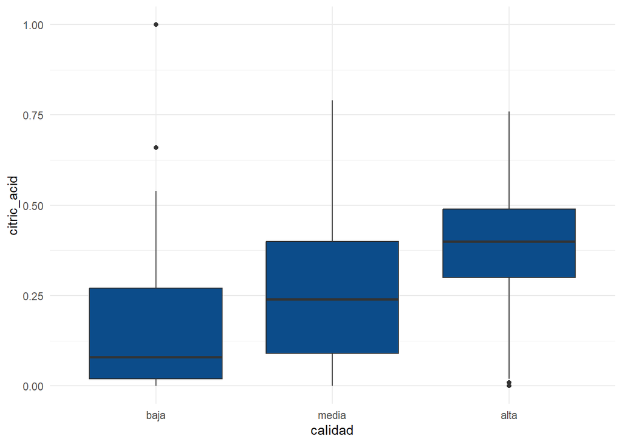

```r
ggplot(data = wine_processed) +
  aes(x = calidad, y = citric_acid) +
  geom_boxplot(fill = "#0c4c8a") +
  theme_minimal()
```

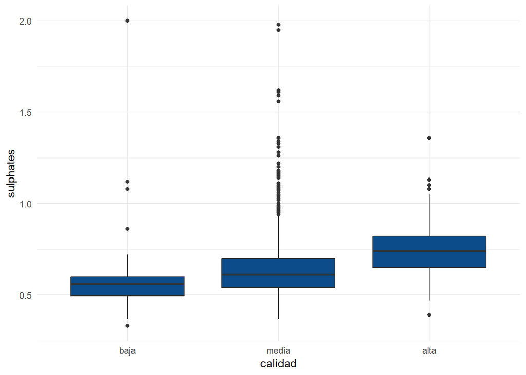

```r
ggplot(data = wine_processed) +
  aes(x = calidad, y = sulphates) +
  geom_boxplot(fill = "#0c4c8a") +
  theme_minimal()
```

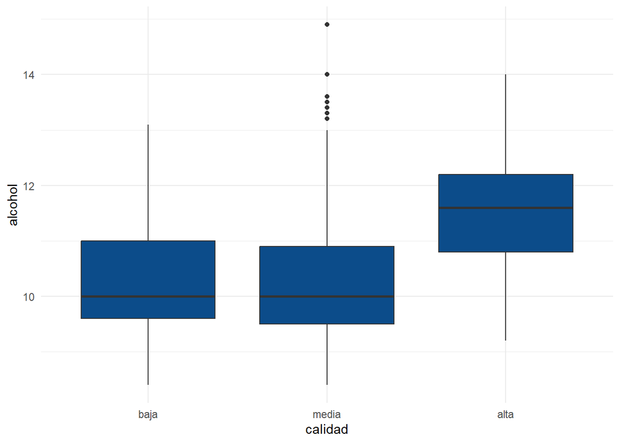

```r
ggplot(data = wine_processed) +
  aes(x = calidad, y = alcohol) +
  geom_boxplot(fill = "#0c4c8a") +
  theme_minimal()
```

Para medir el grado de relación en este escenario, dado que no se pueden calcular correlaciones de Pearson, debemos emplear otras técnicas. La técnica depende principalmente del número de categorías, los supuestos distribucionales y el objetivo del análisis.

Algunas alternativas son:

- **Prueba t de Student**, para comparar dos grupos.
- **ANOVA**, para comparar tres o más grupos.
- **Mann-Whitney**, como alternativa no paramétrica para dos grupos.
- **Kruskal-Wallis**, como alternativa no paramétrica para tres o más grupos.
- **Correlación biserial-puntual**, cuando la variable categórica es dicotómica.

Para este ejemplo utilizaremos la **prueba de Kruskal-Wallis**, que permite evaluar si la distribución de una variable continua presenta diferencias entre los grupos definidos por una variable categórica.

- **Hipótesis nula**: la distribución de la variable continua es igual entre los grupos.
- **Hipótesis alternativa**: al menos uno de los grupos presenta una distribución diferente.

```r
kruskal.test(wine_processed$volatile_acidity, wine_processed$calidad)
```

```
##
##  Kruskal-Wallis rank sum test
##
## data:  wine_processed$volatile_acidity and wine_processed$calidad
## Kruskal-Wallis chi-squared = 168.44, df = 2, p-value < 2.2e-16
```

```r
kruskal.test(wine_processed$citric_acid, wine_processed$calidad)
```

```
##
##  Kruskal-Wallis rank sum test
##
## data:  wine_processed$citric_acid and wine_processed$calidad
## Kruskal-Wallis chi-squared = 86.083, df = 2, p-value < 2.2e-16
```

```r
kruskal.test(wine_processed$sulphates, wine_processed$calidad)
```

```
##
##  Kruskal-Wallis rank sum test
##
## data:  wine_processed$sulphates and wine_processed$calidad
## Kruskal-Wallis chi-squared = 147.44, df = 2, p-value < 2.2e-16
```

```r
kruskal.test(wine_processed$alcohol, wine_processed$calidad)
```

```
##
##  Kruskal-Wallis rank sum test
##
## data:  wine_processed$alcohol and wine_processed$calidad
## Kruskal-Wallis chi-squared = 234.32, df = 2, p-value < 2.2e-16
```

## Caso 3: Asociación entre dos variables categóricas

En este caso una forma habitual de explorar la relación entre las variables es mediante una tabla de contingencia, que resume las frecuencias observadas para cada combinación de categorías.

```r
tbl = table(wine_processed$acetico, wine_processed$calidad)
tbl
```

```
##
##        baja media alta
##   bajo   34  1122  210
##   alto   29   197    7
```

```r
# Damos nombre a las columnas y las filas
colnames(tbl) <- c("Calidad baja", "Calidad media", "Calidad alta")
rownames(tbl) <- c("Ácido acético bajo","Ácido acético alto")
tbl
```

```
##
##                      Calidad baja Calidad media Calidad alta
##   Ácido acético bajo           34          1122          210
##   Ácido acético alto           29           197            7
```

Para evaluar estadísticamente si existe asociación entre las variables puede utilizarse la **prueba de independencia X<sup>2</sup>** (Chi-Cuadrado) de independencia. Esta prueba compara las frecuencias observadas con las frecuencias que se esperarían si ambas variables fueran independientes.

- **Hipótesis nula**: las variables son independientes.
- **Hipótesis alternativa**: existe asociación entre las variables.

Un p-valor pequeño aporta evidencia contra la hipótesis de independencia, pero no indica por sí solo la intensidad de la asociación ni implica una relación causal.

```r
## Prueba Chi-Cuadrado
chisq.test(tbl)
```

```
##
##  Pearson's Chi-squared test
##
## data:  tbl
## X-squared = 72.67, df = 2, p-value < 2.2e-16
```

## Observaciones de cierre

Identificar relaciones entre dos o más variables requiere combinar criterios estadísticos con conocimiento del problema y del contexto. La experiencia, la revisión de literatura y el análisis de casos similares ayudan a orientar esta tarea.

Además,

1. Hay que procurar trabajar con **variables informativas**, es decir, que guarden una relación con la variable objetivo.
2. Hay que evitar las redundancias excesivas entre variables explicativas. Una **alta correlación o multicolinealidad** puede dificultar la interpretación y afectar algunos modelos.
3. La incorporación de más variables no siempre mejora el análisis. Es recomendable buscar un **equilibrio entre capacidad explicativa o predictiva, complejidad e interpretabilidad**, teniendo en cuenta además el tamaño de la muestra (más variables en un modelo = más datos hay que recolectar).

## Práctica aplicada

Elija dos variables de una base y documente:

1. El tipo de cada variable.
2. La visualización elegida para cruzarlas y por qué es apropiada.
3. La medida o prueba utilizada para medir su asociación.
4. Una interpretación que no confunda asociación con causalidad.